# Rewind

Loading c.elegans, no BS

```r
load("~/AvOwork/cele_all_pt.csv")
```

Does adding dG improve the coverage prediction? (Using matching pairs)

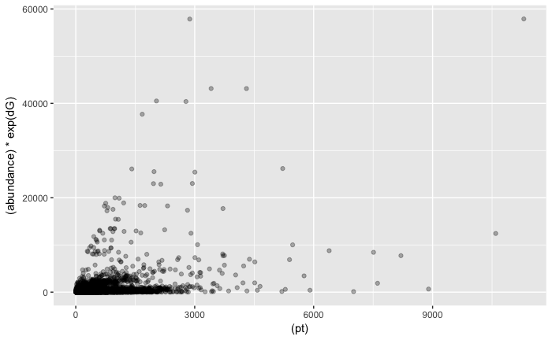

While primer and template usage do not coincide, genomic abundance by itself seems to be a very good predictor of template usage.

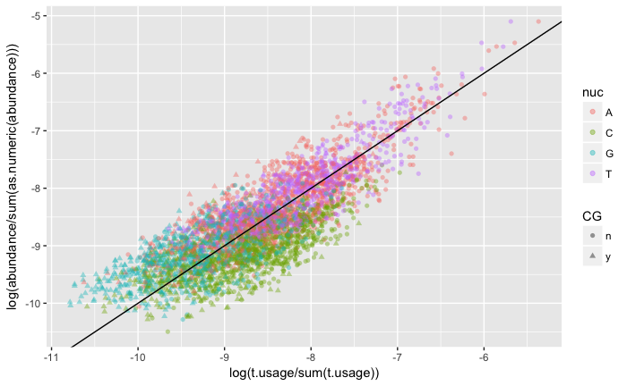

This fits with the model (where T is one of the parameters), but if coverage where simply linearly correlated with genomic abundance we wouldn’t see a bias in the coverage!! (Remember the predicted profile based on occupancy?). The density of binding (template usage/abundance) is not constant and not gaussian, so not a the simple slope for the correlation

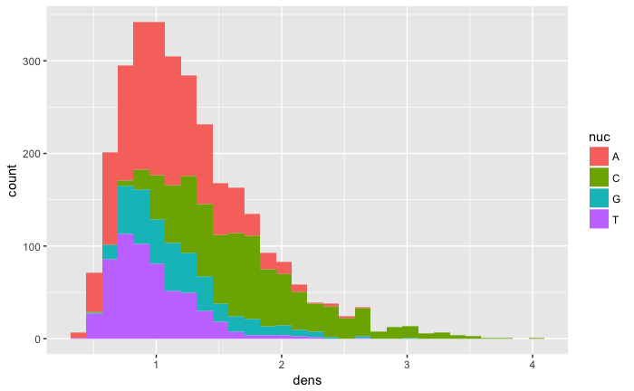

How is that then? Probably the presence of primers plays a role here. If I do multiple linear regression to predict the template usage using the abundance and the number of matching pairs the predictive power improves (the spread is lost, which might explain density differences). Smaae if I put the p.usage instead

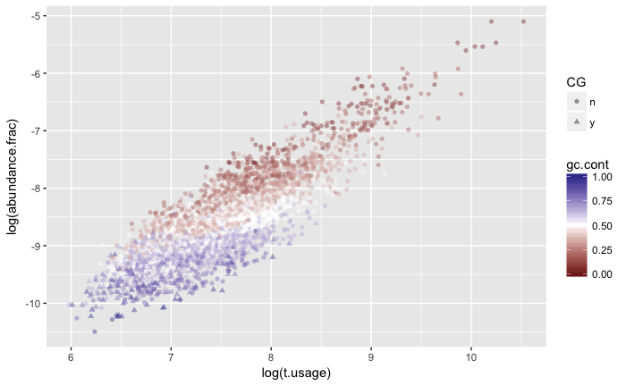

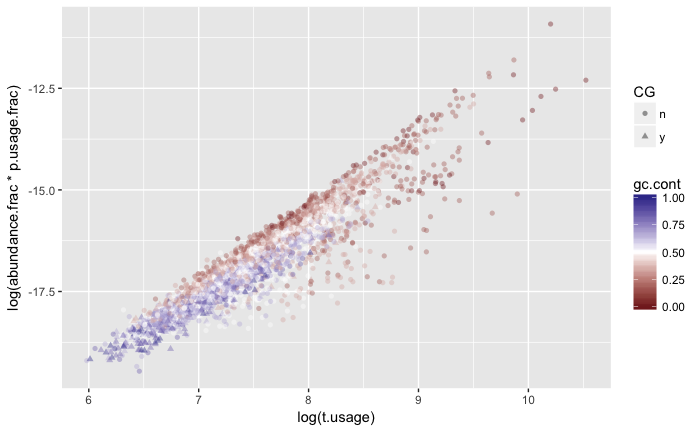

Primer usage follows a distribution that resembles the one of a random primer batch, but with some sequences way more used

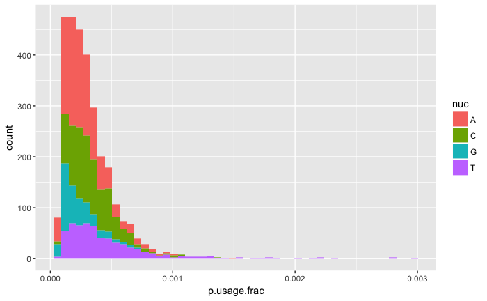

And here I thought: is primer usage just proportional to the original batch (so no one actually binds better than another) or is there more to it? That was true then differences in densities could just be explained by the primer concentration (as in: some sequences are bound more than expected because you simply have more of their primer in the batch)

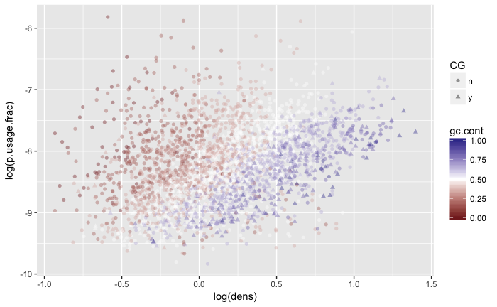

Clearly not.

Also if p.usage was just proportional to what you have in the tube you should see a correlated usage between experiments on different species using the same batch, right?

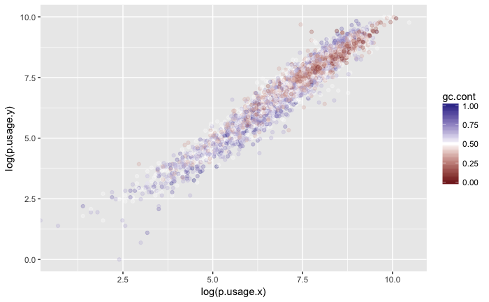

Promiscuity

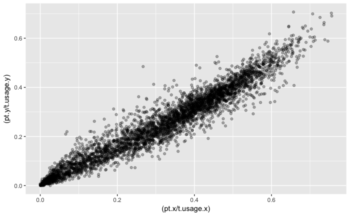

Weeeelll…more than the template usage?

```r
d2r.all.df %>%
  inner_join(., d3r.all.df, by='hex') %>%
  head
```

```
Error: `by` can't contain join column `hex` which is missing from LHS
```

Trying other experiments

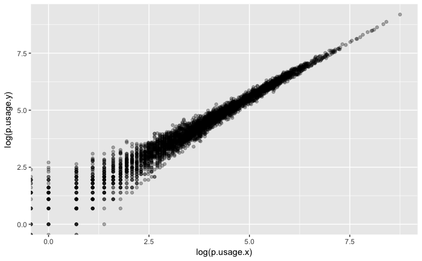

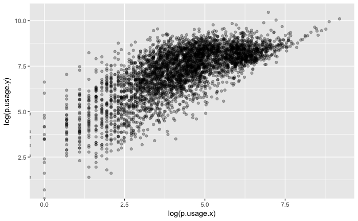

Same organism different batch

```
Column `hex` joining character vector and factor, coercing into character vector
```

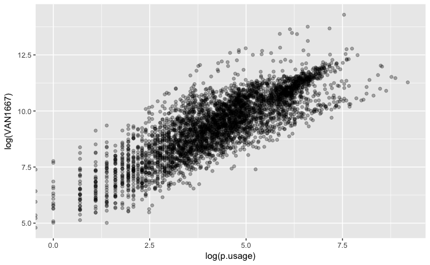

```r
primer.usage.d3 %>%
  inner_join(., primer.usage.VAN1667, by='hex') %>%
  ggplot(., aes(log(p.usage), log(VAN1667))) + geom_point(alpha=0.3)
```

What then?

Interesting observation: abundance is also well correlated with the binding energy.

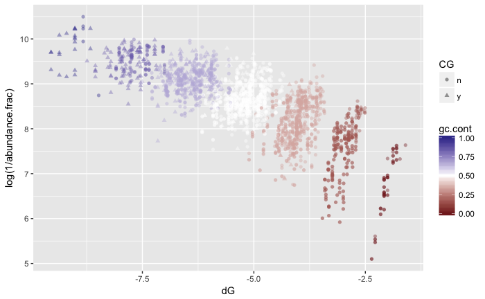

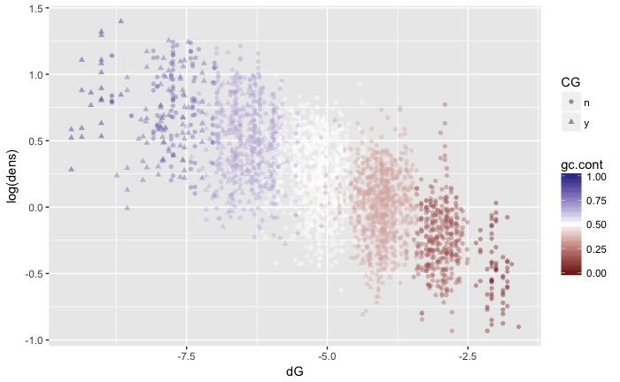

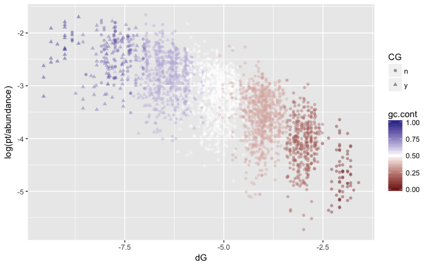

```r
df.w.dens %>%
  filter(pt>300) %>%
  ggplot(., aes(dG, log(1/abundance.frac))) +
  geom_point(alpha=0.4, aes(color=gc.cont, shape=CG)) +
  scale_color_gradient2(midpoint = 0.5)
df.w.dens %>%
  filter(pt>300) %>%
    ggplot(., aes(dG, log(dens))) +
  geom_point(alpha=0.4, aes(color=gc.cont, shape=CG)) +
  scale_color_gradient2(midpoint = 0.5)

df.w.dens %>%
    filter(pt>300) %>%
  ggplot(., aes(dG, log(pt/abundance))) +
  geom_point(alpha=0.4, aes(color=gc.cont, shape=CG)) +
  scale_color_gradient2(midpoint = 0.5)
```

Try the same with different organism

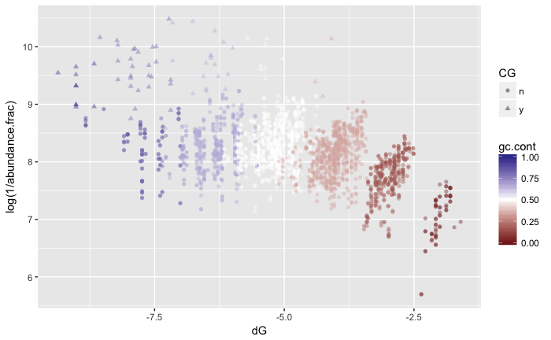

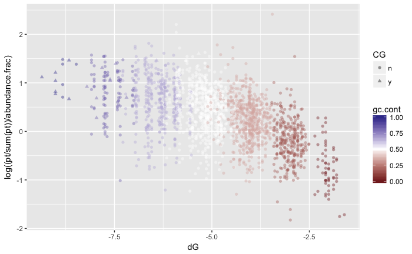

Ok for the human it’s not so truw. So is the abundance still a very good predictor?

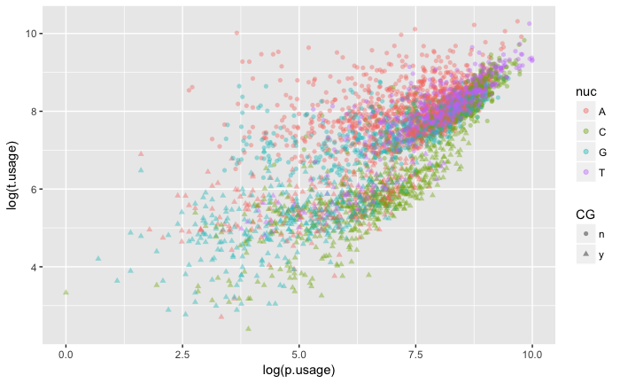

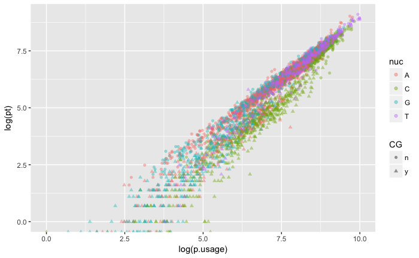

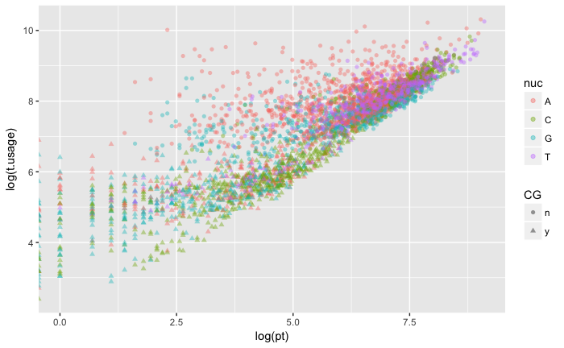

```r
df.human %>%
  ggplot(., aes( log(p.usage), log(t.usage))) +
  geom_point(alpha=0.4, aes(color=nuc, shape=CG))
df.human %>%
  ggplot(., aes( log(p.usage), log(pt))) +
  geom_point(alpha=0.4, aes(color=nuc, shape=CG))

df.human %>%
  ggplot(., aes(log(pt), log(t.usage))) +
  geom_point(alpha=0.4, aes(color=nuc, shape=CG))
```

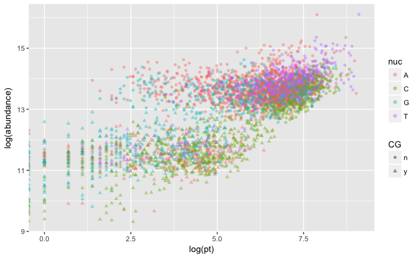

```r
df.human %>%
  ggplot(., aes(log(pt), log(abundance))) +
  geom_point(alpha=0.4, aes(color=nuc, shape=CG))
```

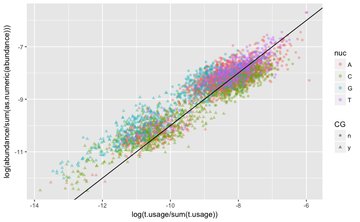

```r
df.human %>%
  ggplot(., aes(log(t.usage/sum(t.usage)), log(abundance/sum(as.numeric(abundance))))) +
  geom_point(alpha=0.4, aes(color=nuc, shape=CG)) +
  geom_abline(slope=1, intercept=0)
```

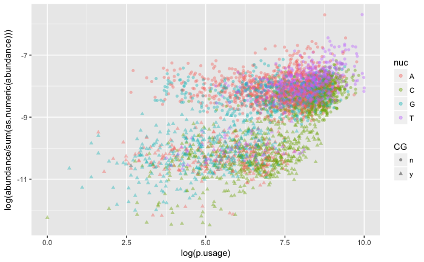

```r
df.human %>%
  ggplot(., aes(log(p.usage), log(abundance/sum(as.numeric(abundance))))) +
  geom_point(alpha=0.4, aes(color=nuc, shape=CG))
```

Yes it is. Wot the hell…

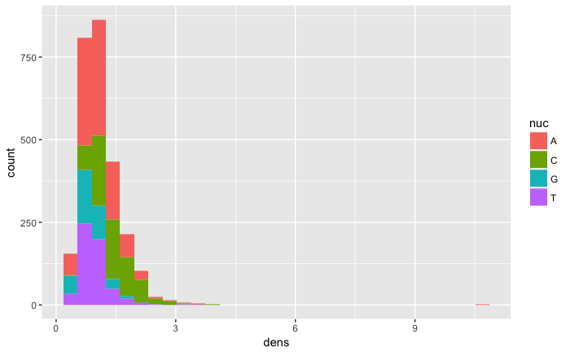

Fitting

```r
lm.1 <- lm(t.usage ~ abundance.frac, data=df.w.dens)
lm.2 <- lm(t.usage ~ abundance.frac * (p.usage.frac), data=df.w.dens)
lm.3 <- lm(t.usage ~ abundance.frac * p.usage.frac * (gc.cont+1), data=df.w.dens)
summary(lm.1)
```

```
Call:
lm(formula = t.usage ~ abundance.frac, data = df.w.dens)

Residuals:
    Min      1Q  Median      3Q     Max
-7518.8  -521.5  -166.7   407.1  9582.6

Coefficients:
                Estimate Std. Error t value Pr(>|t|)
(Intercept)    8.024e+02  2.208e+01   36.35   <2e-16 ***
abundance.frac 5.520e+06  4.895e+04  112.78   <2e-16 ***
---
Signif. codes:  0 ‘***’ 0.001 ‘**’ 0.01 ‘*’ 0.05 ‘.’ 0.1 ‘ ’ 1

Residual standard error: 948.1 on 2969 degrees of freedom
Multiple R-squared:  0.8107,    Adjusted R-squared:  0.8107
F-statistic: 1.272e+04 on 1 and 2969 DF,  p-value: < 2.2e-16
```

```r
summary(lm.2)
```

```
Call:
lm(formula = t.usage ~ abundance.frac * (p.usage.frac), data = df.w.dens)

Residuals:
    Min      1Q  Median      3Q     Max
-5663.9  -247.3   -71.8   158.1 10285.2

Coefficients:
                              Estimate Std. Error t value Pr(>|t|)
(Intercept)                 -6.797e+01  2.821e+01  -2.409    0.016 *
abundance.frac               5.473e+06  6.008e+04  91.093   <2e-16 ***
p.usage.frac                 3.103e+06  7.402e+04  41.918   <2e-16 ***
abundance.frac:p.usage.frac -8.936e+08  5.054e+07 -17.682   <2e-16 ***
---
Signif. codes:  0 ‘***’ 0.001 ‘**’ 0.01 ‘*’ 0.05 ‘.’ 0.1 ‘ ’ 1

Residual standard error: 751.4 on 2967 degrees of freedom
Multiple R-squared:  0.8812,    Adjusted R-squared:  0.8811
F-statistic:  7335 on 3 and 2967 DF,  p-value: < 2.2e-16
```

```r
summary(lm.3)
```

```
Call:
lm(formula = t.usage ~ abundance.frac * p.usage.frac * (gc.cont +
    1), data = df.w.dens)

Residuals:
    Min      1Q  Median      3Q     Max
-5885.3  -253.9   -58.2   158.4  9658.7

Coefficients:
                                      Estimate Std. Error t value Pr(>|t|)
(Intercept)                          1.751e+02  8.277e+01   2.116 0.034454 *
abundance.frac                       5.676e+06  7.731e+04  73.415  < 2e-16 ***
p.usage.frac                         6.361e+05  2.326e+05   2.735 0.006275 **
gc.cont                             -6.320e+02  1.381e+02  -4.576 4.94e-06 ***
abundance.frac:p.usage.frac         -5.628e+08  6.416e+07  -8.772  < 2e-16 ***
abundance.frac:gc.cont               8.239e+05  4.449e+05   1.852 0.064149 .
p.usage.frac:gc.cont                 4.197e+06  4.000e+05  10.493  < 2e-16 ***
abundance.frac:p.usage.frac:gc.cont  2.024e+09  5.370e+08   3.768 0.000168 ***
---
Signif. codes:  0 ‘***’ 0.001 ‘**’ 0.01 ‘*’ 0.05 ‘.’ 0.1 ‘ ’ 1

Residual standard error: 729 on 2963 degrees of freedom
Multiple R-squared:  0.8883,    Adjusted R-squared:  0.8881
F-statistic:  3367 on 7 and 2963 DF,  p-value: < 2.2e-16
```

```r
summary(lm.3)
```

[output not shown]

Primer usage

```r
primer.usage.d3t <- d3t.all.df %>%
  group_by(primer) %>%
  summarise(p.usage= sum(pt)) %>%
  rename(hex=primer)

primer.usage.d3t %>%
  mutate(nuc=sapply(hex,prevalent_nucleotide),
         p.usage.frac=p.usage/sum(p.usage)) %>%
  ggplot(., aes(p.usage.frac)) + geom_histogram(aes(fill=nuc))

r.pool <- simulate.primer.pool()
data.frame(table(r.pool)) %>%
  rename(hex=r.pool) %>%
  inner_join(., primer.usage.cele, by='hex') %>%
    mutate(nuc=sapply(hex,prevalent_nucleotide),
         p.usage.frac=p.usage/sum(p.usage)) %>%
  ggplot(., aes(log(Freq),log(p.usage), color=nuc)) + geom_point(alpha=0.4)
#
# df <- d3r..df %>%
#   dplyr::select(template, t.usage,pt, abundance) %>%
#   rename(hex=template) %>%
#   inner_join(., primer.usage.cele, by='hex') %>%
#   mutate(nuc=sapply(hex,prevalent_nucleotide),
#          CG=ifelse(grepl(pattern = 'CG', hex), 'y', 'n'))
#
```

[output not shown]